# Week 4: Batch correction, part 2 — integrating two studies, and correcting the expression matrix

Kevin Z. Lin

2026-08-17

> **A note on `cache = TRUE` and `autodep`.** As with the other two Week 4 documents, every chunk is cached, so later knits take a couple of minutes. The slowest step in this document does not run here at all — see *Running the slow step somewhere else* below — so the first knit is dominated by the two downloads rather than by computation. Chunks whose only output is a figure are marked `cache=FALSE`, because a `ggplot` object stores the environment it was built in and caching one can drag a copy of the whole Seurat object onto disk. `autodep = TRUE` plus `knitr::dep_auto()` makes `knitr` re-run a chunk when the objects it reads have changed — without it a fixed bug upstream can leave a stale figure downstream, with nothing to warn you. Delete `_cache/` and knit once from clean before the document leaves your hands, and exclude `_cache/` from Dropbox or OneDrive syncing.

# 1 Overview

This tutorial was made from the Seurat v4 vignette *Introduction to scRNA-seq integration*, https://satijalab.org/seurat/archive/v4.3/integration_introduction, and *Mapping and annotating query datasets*, https://satijalab.org/seurat/articles/integration_mapping.

**Week 3 stopped one step short on purpose.** It ran `IntegrateLayers()`, got a new *reduction* — a set of coordinates with no gene names attached — and said, in so many words: some methods can also give you a corrected expression matrix, it is tempting to test genes on it, do not, and Week 4 will explain why. This is that explanation, and it starts by actually building one.

Two things are different here.

**The batch is a whole study.** Week 3’s batches were nine protocols run on the same PBMCs. Here the two batches are two independent research programs — SEA-AD in Seattle and ROSMAP through MIT and Rush — with different dissections, different chemistries, different reference annotations, different QC decisions, and no shared donors at all. This is the hard case, and it is also the common one: it is what happens the moment you want to say anything about your data in the context of somebody else’s.

**The output is an expression matrix, not just an embedding.** `FindIntegrationAnchors()` followed by `IntegrateData()` returns an object with a second **assay** in it, whose values are genes × cells and which you can put straight into `FeaturePlot()`, `DotPlot()`, or — and this is the whole point of the tutorial — into `FindMarkers()`, where it will cheerfully give you p-values that mean nothing.

**And there is a third thing, which is not about integration at all.** This document is split across two machines. The anchor-finding, the correction and the label transfer are shown here but not run here: they live in `crossdataset-integration_server.R`, which you submit to a cluster with `crossdataset-integration_server.slurm`, and which writes one file that you copy back and load. **Getting a long-running R job off your laptop and onto a server is a workshop goal in its own right**, and it is the part of this tutorial that transfers directly to your own data — every attendee with a dataset larger than a few thousand cells will need it, whatever method they end up running.

Be clear about what is and is not being claimed there. On *this* pair of datasets the three calls take about **five minutes** on a laptop. They are on a server because a five-minute job is the right size to learn the mechanics on, not because they have to be — and the same script, on data three times the size, is where the habit starts paying. The section *Running the slow step somewhere else* has the measured numbers for both.

The plan:

| Stage | What it produces | Function |
| --- | --- | --- |
| 1. Make the two objects comparable | One shared brain region, shared barcodes, shared genes, comparable sizes | `subset()`, `RenameCells()` |
| 2. Look at them uncorrected | A UMAP with one island per study | `merge()`, `RunPCA()`, `RunUMAP()` |
| 3. Measure the separation | A per-cell batch-mixing score, against its null | `RANN::nn2()` |
| 4. Send the slow part to a server | A batch job, and one file to copy back | `sbatch`, `scp` |
| 5. Find anchors *(on the server)* | Pairs of cells the method believes are the same cell | `FindIntegrationAnchors()` |
| 6. Correct the expression *(on the server)* | A new **assay**, `integrated`, of corrected values | `IntegrateData()` |
| 7. Load the result, and check it | The server’s object, verified against your own | `load()`, `identical()` |
| 8. Look inside it | Fewer genes, no counts, and negative numbers | `LayerData()` |
| 9. Re-embed, and re-measure | The same mixing score, on corrected values | `RunPCA()`, `RunUMAP()` |
| 10. Go back to the counts | The assay you actually test on | `JoinLayers()` |
| 11. The alternative *(on the server)* | Reference labels moved onto the query, counts untouched | `TransferData()` |

> **Where this sits in the workshop.** This is the second half of batch correction. **Week 3** produced an integrated reduction on nine PBMC protocols and judged it by eye against labels fixed beforehand; this one produces a corrected expression matrix across two studies and judges it with a number. The companion Week 4 tutorials cluster this dataset and test genes between donors. Bulk deconvolution is **Week 5**.

# 2 Setting up

```r
# install.packages(c("Seurat", "RANN", "ggplot2", "patchwork"))
```

```r
library(Seurat)
library(SeuratObject)
library(RANN)
library(ggplot2)
library(patchwork)
```

```r
rm(list = ls())
```

# 3 The data: two studies, one brain region

**SEA-AD** (Seattle Alzheimer’s Disease Brain Cell Atlas) profiled middle temporal gyrus across an aged cohort spanning the full range of Alzheimer’s neuropathology. The file is the same one the other two Week 4 tutorials use: the microglia and perivascular-macrophage subset, 40,000 nuclei from 89 donors, with the authors’ own `Supertype` annotation.

**ROSMAP**, as analysed by Sun *et al.* (2023), profiled immune cells from six brain regions across 425 participants of the Religious Orders Study and Rush Memory and Aging Project, and assigned each microglial nucleus one of thirteen **states**, `MG0` through `MG12`. The file here is the whole of that microglial set — 133,007 nuclei across all six regions — and the very first thing this tutorial does to it is throw five of the six regions away. Why, in a moment.

```r
data_dir <- tempdir(check = TRUE)

# If you have already downloaded either file, point data_dir at the folder
# holding them and the downloads below will be skipped, e.g.:
# data_dir <- "/path/to/your/data"
```

```r
options(timeout = 3600)

seaad_url <- paste0("https://www.dropbox.com/scl/fi/cei02rwh3gx61uu9zzeql/",
                    "seaad_microglia.RData",
                    "?rlkey=04erfwn3w2lrnr80pefwfh8fu&dl=1")
seaad_file <- file.path(data_dir, "seaad_microglia.RData")
seaad_size <- 525672784

if (!file.exists(seaad_file) || file.size(seaad_file) != seaad_size) {
  download.file(seaad_url, destfile = seaad_file, mode = "wb")
}

file.size(seaad_file) == seaad_size
```

```
## [1] TRUE
```

```r
rosmap_url <- paste0("https://www.dropbox.com/scl/fi/siecgiljoks48pkin42ts/",
                     "rosmap_microglia.RData",
                     "?rlkey=vwnmoeynhbsuxkiumz36hy301&dl=1")
rosmap_file <- file.path(data_dir, "rosmap_microglia.RData")
rosmap_size <- 1507998516

if (!file.exists(rosmap_file) || file.size(rosmap_file) != rosmap_size) {
  download.file(rosmap_url, destfile = rosmap_file, mode = "wb")
}

file.size(rosmap_file) == rosmap_size
```

```
## [1] TRUE
```

> **`options(timeout = 3600)`, `dl=1`, and `mode = "wb"`** are the same three download details the other Week 4 tutorials open with, and they matter for the same reasons: R’s default 60-second timeout truncates a large file and reports it as a *warning*; a Dropbox link copied from the Share button ends in `dl=0` and serves an HTML preview page; and without binary mode the file is silently corrupted on Windows. The size comparison is there to check the bytes you got are the bytes you wanted.

```r
load(seaad_file)
load(rosmap_file)

ls()
```

```
## [1] "data_dir"    "rosmap"      "rosmap_file" "rosmap_size" "rosmap_url"
## [6] "seaad_file"  "seaad_size"  "seaad_url"   "seurat_obj"
```

```r
seaad <- seurat_obj
rm(list = c("seurat_obj")); gc(TRUE)
```

```
##              used   (Mb) gc trigger    (Mb) limit (Mb)   max used   (Mb)
## Ncells    3999064  213.6    6785222   362.4         NA    5108075  272.9
## Vcells 1280086778 9766.3 1829741892 13959.9     102400 1280355984 9768.4
```

```r
seaad
```

```
## An object of class Seurat
## 36412 features across 40000 samples within 1 assay
## Active assay: RNA (36412 features, 0 variable features)
##  2 layers present: counts, data
##  2 dimensional reductions calculated: scVI, umap
```

```r
rosmap
```

```
## An object of class Seurat
## 16219 features across 133007 samples within 1 assay
## Active assay: RNA (16219 features, 2000 variable features)
##  3 layers present: counts, data, scale.data
##  2 dimensional reductions calculated: pca, umap
```

```r
SeuratObject::Layers(seaad[["RNA"]])
```

```
## [1] "counts" "data"
```

```r
length(unique(seaad$donor_id))
```

```
## [1] 89
```

```r
table(seaad$Supertype)
```

```
##
##         Micro-PVM_1 Micro-PVM_1_1-SEAAD         Micro-PVM_2 Micro-PVM_2_1-SEAAD
##                1621                 260               22427                 289
## Micro-PVM_2_2-SEAAD Micro-PVM_2_3-SEAAD   Micro-PVM_3-SEAAD   Micro-PVM_4-SEAAD
##                 855                9019                5107                 422
```

```r
SeuratObject::Layers(rosmap[["RNA"]])
```

```
## [1] "counts"     "data"       "scale.data"
```

```r
Seurat::Reductions(rosmap)
```

```
## [1] "pca"  "umap"
```

```r
colnames(rosmap@meta.data)
```

```
##  [1] "orig.ident"      "nCount_RNA"      "nFeature_RNA"    "subject"
##  [5] "brainRegion"     "batch"           "barcode"         "percent.mt"
##  [9] "age_death"       "msex"            "pmi"             "ADdiag3types"
## [13] "percent.rp"      "seurat_clusters" "State"
```

```r
length(unique(rosmap$subject))
```

```
## [1] 425
```

```r
table(rosmap$brainRegion)
```

```
##
##      AngularGyrus  EntorhinalCortex       Hippocampus MidtemporalCortex
##              6784             18761             23129              9354
##               PFC          Thalamus
##             56306             18673
```

```r
table(rosmap$State)
```

```
##
##   MG0   MG1  MG10  MG11  MG12   MG2   MG3   MG4   MG5   MG6   MG7   MG8
## 34780 26405  2919  2050  1571 18475 14462 10869  7603  2855  5599  5419
```

```r
table(rosmap$ADdiag3types)
```

```
##
## earlyAD  lateAD   nonAD
##   38446   22932   71629
```

Two asymmetries are already visible and neither goes away.

**Each file arrives carrying somebody else’s analysis, and not the same analysis.** That both objects came to us processed is normal and is not the problem; that they were processed differently is. SEA-AD has `counts` and a log-normalized `data` layer, and carries the authors’ own `scVI` embedding plus a UMAP built from it — a published, deliberate product, and the thing the companion Week 4 clustering tutorial clusters on. ROSMAP has `counts`, `data` **and** `scale.data`, a generic `pca`/`umap` pair, and a `seurat_clusters` column: somebody’s clustering, at some resolution, computed on all six regions at once.

None of it is wrong and none of it is usable here. We renormalize both studies below, which replaces the inherited `data` layers; and nothing in this tutorial ever reads the inherited `scale.data`, the inherited reductions, or `seurat_clusters`, all of which describe cells and gene sets we are about to change. The habit worth taking is smaller than it sounds — **know which columns and layers in an object you computed and which arrived in the file** — because a `seurat_clusters` that came with a download looks exactly like one you produced, right up until it appears in a figure you are calling your result.

**And the two studies do not use the same vocabulary for cell identity.** SEA-AD has eight `Supertype` labels built around microglia/PVM subdivisions; ROSMAP has `State` labels built around activation programs — twelve of Sun *et al.*’s thirteen are present in this file, `MG9` being absent. Neither is wrong, and there is no dictionary between them. That is the normal situation when you put two studies side by side, and the last section of this tutorial is about what you can do with it.

# 4 Making the two objects comparable

Four things have to be reconciled before any integration method will touch them: brain region, barcodes, genes, and size.

## 4.1 Region

```r
target_region <- "MidtemporalCortex"

table(rosmap$brainRegion)
```

```
##
##      AngularGyrus  EntorhinalCortex       Hippocampus MidtemporalCortex
##              6784             18761             23129              9354
##               PFC          Thalamus
##             56306             18673
```

```r
tapply(rosmap$batch, rosmap$brainRegion, function(x){ length(unique(x)) })
```

```
##      AngularGyrus  EntorhinalCortex       Hippocampus MidtemporalCortex
##                 1                 1                 1                 1
##               PFC          Thalamus
##                15                 1
```

```r
rosmap_cells <- Seurat::Cells(rosmap)[rosmap$brainRegion == target_region]
rosmap <- subset(rosmap, cells = rosmap_cells)

ncol(rosmap)
```

```
## [1] 9354
```

```r
length(unique(rosmap$subject))
```

```
## [1] 48
```

```r
table(rosmap$batch)
```

```
##
## MidtemporalCortex
##              9354
```

> **Matching the region is the most important design decision in this tutorial, and it costs 93% of the ROSMAP nuclei.** Prefrontal cortex is ROSMAP’s largest region by far — six times as many microglia as middle temporal cortex, and the obvious thing to reach for if what you want is cells. Pairing SEA-AD’s middle temporal gyrus against it would have made **study** and **brain region** the same variable. Every difference between the two would then have two explanations, the integration would remove both, and no diagnostic could tell you which one you had lost. Week 3 made the same check with one line, `table(Method, Experiment)`, and found partial confounding in a dataset designed to be clean.

> Keeping all six regions is worse than picking the wrong one, not better. Region would then vary *inside* one of the two batches, leaving the anchors free to align a middle-temporal-gyrus nucleus to a thalamic one; and the ROSMAP side would outnumber the SEA-AD side thirteen to one, which is a second and independent problem — see *Size* below.

> Matching the region does not make the two studies comparable. It removes one named reason they are not.

> **`batch` is not a sequencing batch here, and reading it as one would mislead you.** Look at the second line of that chunk: five of ROSMAP’s six regions have exactly one `batch` value, and it is the region’s own name. Only prefrontal cortex is resolved further, into fourteen `SM_*` run identifiers plus a residual `PFC`. So `table(rosmap$batch)` reporting a single batch for middle temporal cortex is **not** evidence that it was sequenced in one go — it is the absence of that information, wearing the same shape as an answer. Check what a metadata column contains before you build an argument on it; this one is called `batch` and sits right beside columns that do mean what they say.

## 4.2 Barcodes

```r
utils::head(Seurat::Cells(seaad), 3)
```

```
## [1] "GTTACAGGTGTAGTGG-L8TX_210513_01_C09-1142430429"
## [2] "GAATAGAAGCCGATTT-L8TX_210325_01_E07-1153814170"
## [3] "GTGACGCGTGTTTCTT-L8TX_210107_02_B12-1142430363"
```

```r
utils::head(Seurat::Cells(rosmap), 3)
```

```
## [1] "MidtemporalCortex.AAAGTCCGTTCAAGTC-1"
## [2] "MidtemporalCortex.AACAAGAGTGATACAA-1"
## [3] "MidtemporalCortex.AAGCATCCACTAGGCC-1"
```

```r
seaad <- Seurat::RenameCells(seaad, add.cell.id = "seaad")
rosmap <- Seurat::RenameCells(rosmap, add.cell.id = "rosmap")

utils::head(Seurat::Cells(seaad), 3)
```

```
## [1] "seaad_GTTACAGGTGTAGTGG-L8TX_210513_01_C09-1142430429"
## [2] "seaad_GAATAGAAGCCGATTT-L8TX_210325_01_E07-1153814170"
## [3] "seaad_GTGACGCGTGTTTCTT-L8TX_210107_02_B12-1142430363"
```

```r
utils::head(Seurat::Cells(rosmap), 3)
```

```
## [1] "rosmap_MidtemporalCortex.AAAGTCCGTTCAAGTC-1"
## [2] "rosmap_MidtemporalCortex.AACAAGAGTGATACAA-1"
## [3] "rosmap_MidtemporalCortex.AAGCATCCACTAGGCC-1"
```

Cell barcodes are drawn from a fixed 10x whitelist, so two experiments will share thousands of them. `merge()` would deduplicate silently by appending suffixes, and you would end up with an object whose cell names no longer match the ones in any table you saved earlier.

As it happens neither of these two would have collided: look at the barcodes before the rename, and SEA-AD has already appended a library ID to each one while ROSMAP has already prefixed each with the brain region. But you cannot know that before you look, the check is one line, and `RenameCells()` is free — so do it anyway. Note also that ROSMAP’s existing prefix is exactly the habit the next callout argues against.

```r
seaad$dataset <- "SEA-AD"
rosmap$dataset <- "ROSMAP"
```

> **Record the batch as metadata, not as a prefix on the barcode.** It is tempting to recover it later with something like `strsplit(cell_name, "_")[[1]][1]`, and that works right up until a barcode contains an underscore of its own — at which point the parse quietly returns the wrong answer for a subset of your cells. One extra column costs nothing.

## 4.3 Genes

```r
length(rownames(seaad))
```

```
## [1] 36412
```

```r
length(rownames(rosmap))
```

```
## [1] 16219
```

```r
common_genes <- intersect(rownames(seaad), rownames(rosmap))
length(common_genes)
```

```
## [1] 15750
```

```r
length(setdiff(rownames(seaad), common_genes))
```

```
## [1] 20662
```

```r
length(setdiff(rownames(rosmap), common_genes))
```

```
## [1] 469
```

```r
seaad <- subset(seaad, features = common_genes)
rosmap <- subset(rosmap, features = common_genes)

dim(seaad)
```

```
## [1] 15750 40000
```

```r
dim(rosmap)
```

```
## [1] 15750  9354
```

> **An intersection is a lossy join, and the loss is not symmetric.** The two studies aligned to different genome annotation releases, so a gene can be missing from one side because it was renamed, because it was retired, or because that study filtered it out. Look at the two `setdiff()` counts above: whichever side loses more is the side whose gene list was longer, which usually means it kept features the other one discarded — antisense transcripts, lncRNAs, and unnamed `ENSG` loci.

> Anchors are matched by gene *name*, so the row order after subsetting does not matter. What does matter is that a gene you care about can simply be absent from `common_genes`, and nothing will tell you. If a specific marker is central to your question, check for it by name before you spend an hour integrating.

## 4.4 Size

```r
ncol(seaad)
```

```
## [1] 40000
```

```r
ncol(rosmap)
```

```
## [1] 9354
```

```r
set.seed(10)
seaad_cells <- sample(Seurat::Cells(seaad), size = 10000)
seaad <- subset(seaad, cells = seaad_cells)

ncol(seaad)
```

```
## [1] 10000
```

```r
ncol(rosmap)
```

```
## [1] 9354
```

> **Anchor-based integration is sensitive to gross imbalance in dataset size.** Anchors are mutual nearest neighbours; a cell in the small dataset has far more candidate partners in the large one than the other way round, so the correction is estimated much better in one direction than the other. Forty thousand against nine and a third thousand is more than four to one, and downsampling is the cheapest way to remove that as an explanation for whatever we see.

> It also makes the mixing score below interpretable: with two batches of equal size, “perfectly mixed” means half of every cell’s neighbours come from the other study, and 0.5 is a number you can hold in your head. And it makes the tutorial knit in a workshop-sized amount of time — which is a real reason, just not a methodological one, and the two should not be confused.

> On your own data, downsampling to balance is a defensible choice you should **state in your methods**, not a default. Throwing away 30,000 measured nuclei is not free.

## 4.5 Normalization and variable genes, within each study

```r
seaad <- Seurat::NormalizeData(seaad, verbose = FALSE)
rosmap <- Seurat::NormalizeData(rosmap, verbose = FALSE)

seaad <- Seurat::FindVariableFeatures(seaad, selection.method = "vst",
                                      nfeatures = 2000, verbose = FALSE)
rosmap <- Seurat::FindVariableFeatures(rosmap, selection.method = "vst",
                                       nfeatures = 2000, verbose = FALSE)

length(intersect(Seurat::VariableFeatures(seaad),
                 Seurat::VariableFeatures(rosmap)))
```

```
## [1] 942
```

```r
integration_features <- Seurat::SelectIntegrationFeatures(
  object.list = list(seaad, rosmap),
  nfeatures = 2000,
  verbose = FALSE)

length(integration_features)
```

```
## [1] 2000
```

```r
utils::head(integration_features, 20)
```

```
##  [1] "F13A1"    "SLC16A10" "NAMPT"    "CCL4"     "SERPINE1" "PTPRG"
##  [7] "FGF13"    "CCL3"     "CD83"     "TFRC"     "GRID2"    "IL1B"
## [13] "SLC2A3"   "DIAPH3"   "CYP19A1"  "FCGBP"    "CCL4L2"   "FTH1"
## [19] "NR4A3"    "COLEC12"
```

Fewer than half of the two 2,000-gene lists agree — 942 genes of 2,000, between two studies of the same cell type in the same brain region. Each study’s variable genes partly describe that study’s technical character, which is exactly why the gene selection has to happen **inside** each batch and then be combined — `SelectIntegrationFeatures()` ranks a gene by how often it is variable across the datasets, so a gene that is only variable because of one study’s chemistry loses to a gene that is variable in both.

> **Run `FindVariableFeatures()` on the naively merged object and you select the batch effect.** A gene that is high in study A and low in study B has enormous variance in the pooled data, which is precisely what “highly variable” is measuring. You then hand those genes to PCA and wonder why PC1 is the study. Seurat v5 makes the right thing the default — `merge()` keeps one layer per dataset and `FindVariableFeatures()` operates per layer — but the trap is still live in any code that joins the layers first.

# 5 What the two studies look like uncorrected

```r
merged <- merge(seaad, rosmap)
merged
```

```
## An object of class Seurat
## 15750 features across 19354 samples within 1 assay
## Active assay: RNA (15750 features, 2000 variable features)
##  5 layers present: counts.1, counts.2, data.1, data.2, scale.data.2
```

```r
SeuratObject::Layers(merged[["RNA"]])
```

```
## [1] "counts.1"     "counts.2"     "data.1"       "data.2"       "scale.data.2"
```

```r
table(merged$dataset)
```

```
##
## ROSMAP SEA-AD
##   9354  10000
```

The layers stayed separate. That is Seurat v5’s representation of “these cells came from different places”, and it is what lets the pipeline below behave per-batch without being told to.

Note the fifth layer, `scale.data.2`. That is ROSMAP’s inherited scaling from earlier, riding along into the merged object with no counterpart on the SEA-AD side. Nothing here reads it — `ScaleData()` on the next line writes its own — but it is a tidy illustration of how a layer you never created survives a subset, a rename and a merge, and ends up inside an object you think of as yours.

```r
merged <- Seurat::NormalizeData(merged, verbose = FALSE)
merged <- Seurat::FindVariableFeatures(merged, selection.method = "vst",
                                       nfeatures = 2000, verbose = FALSE)
merged <- Seurat::ScaleData(merged, verbose = FALSE)

set.seed(10)
merged <- Seurat::RunPCA(merged,
                         features = Seurat::VariableFeatures(merged),
                         npcs = 30,
                         reduction.name = "pca.uncorrected",
                         verbose = FALSE)

set.seed(10)
merged <- Seurat::RunUMAP(merged,
                          reduction = "pca.uncorrected",
                          dims = 1:30,
                          reduction.name = "umap.uncorrected",
                          seed.use = 10,
                          verbose = FALSE)

Seurat::Reductions(merged)
```

```
## [1] "pca.uncorrected"  "umap.uncorrected"
```

Every reduction here is given an explicit `reduction.name`. The defaults are `pca` and `umap`, and a second `RunPCA()` later in the document would overwrite the first without comment — leaving you comparing a corrected embedding against itself. Naming them costs one argument and removes the possibility.

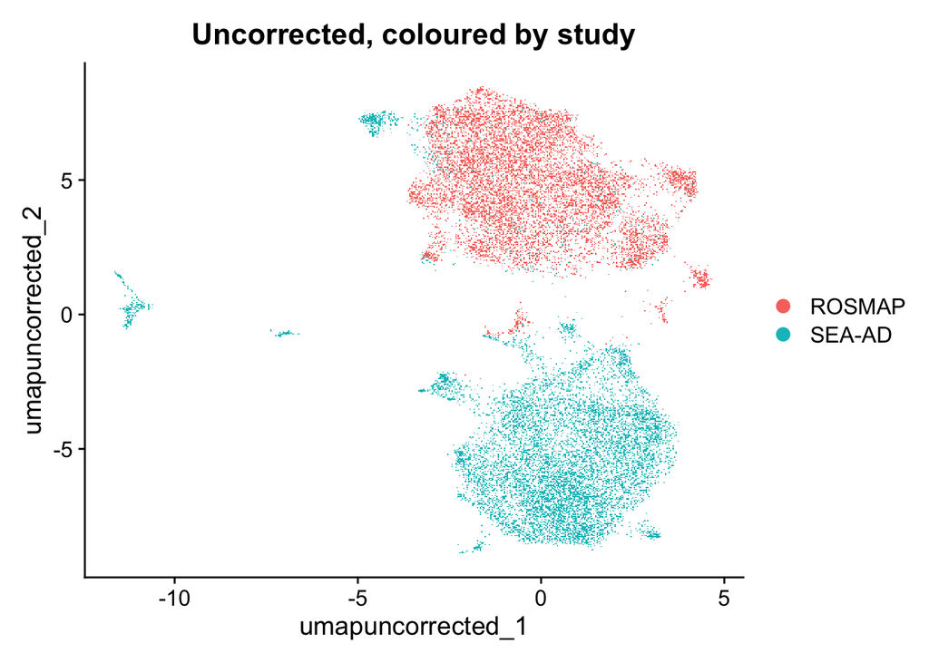

```r
gg <- Seurat::DimPlot(merged, reduction = "umap.uncorrected",
                      group.by = "dataset", raster = TRUE)
gg <- gg + ggplot2::ggtitle("Uncorrected, coloured by study")
plot(gg)
```

Overplotting can hide a lot in a two-colour UMAP — whichever study is drawn second sits on top. `split.by` draws one panel per batch on shared axes, which is the honest version of the same figure.

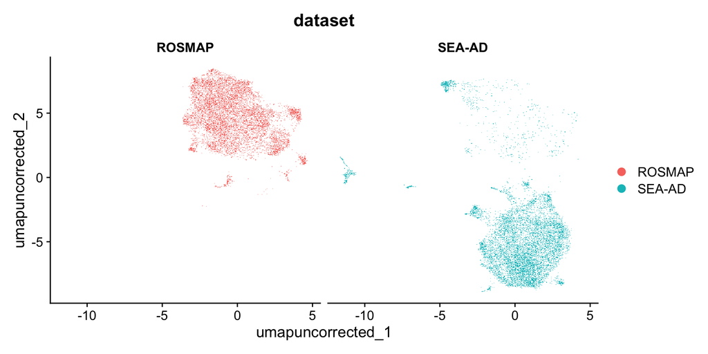

```r
gg <- Seurat::DimPlot(merged, reduction = "umap.uncorrected",
                      group.by = "dataset", split.by = "dataset",
                      raster = TRUE)
plot(gg)
```

## 5.1 Measuring the separation instead of describing it

Week 3 judged its integration by eye and said so. A picture is genuinely informative here, but it is also the thing most easily talked into agreeing with you, and “the batches look reasonably mixed” is not a sentence a reviewer can check. The number below is cheap and it is the core idea behind the published integration metrics.

For each cell, find its `k` nearest neighbours in the embedding and ask what fraction of them came from the *other* study.

```r
neighbor_mixing <- function(embedding_mat, batch_vec, k = 30){
  # nn2 returns each point as its own first neighbour, so drop column 1.
  nn_out <- RANN::nn2(data = embedding_mat, k = k + 1)
  nn_idx <- nn_out$nn.idx[, -1, drop = FALSE]

  # batch_vec[nn_idx] unwinds column-major, so rebuild the matrix with the same
  # nrow to keep cell i on row i.
  neighbor_batch_mat <- matrix(batch_vec[nn_idx], nrow = nrow(nn_idx))

  rowMeans(neighbor_batch_mat != batch_vec)
}
```

```r
dataset_vec <- merged$dataset
dataset_share <- table(dataset_vec) / length(dataset_vec)
dataset_share
```

```
## dataset_vec
##    ROSMAP    SEA-AD
## 0.4833109 0.5166891
```

```r
# Under perfect mixing, a cell's neighbours are a random sample of everything
# else, so the expected other-study fraction is one minus its own study's share.
1 - dataset_share
```

```
## dataset_vec
##    ROSMAP    SEA-AD
## 0.5166891 0.4833109
```

```r
mixing_uncorrected <- neighbor_mixing(
  embedding_mat = Seurat::Embeddings(merged, "pca.uncorrected")[, 1:30],
  batch_vec = dataset_vec,
  k = 30)

tapply(mixing_uncorrected, dataset_vec, stats::median)
```

```
## ROSMAP SEA-AD
##      0      0
```

Compare the two: the median observed against the value the second line predicts. The observed medians are not *near* zero, they are **zero**, for both studies — the thirty nearest neighbours of a typical nucleus, in a thirty-dimensional space, all came from its own study. The strongest thing about a nucleus in this embedding is which lab sequenced it, and it is not close.

> **A mixing score alone rewards vandalism.** A method that mapped every cell to the same point would land exactly on the null for both studies — a perfect score, from an embedding containing nothing at all. Mixing is only half of the criterion; the other half is that biological structure survived, which is why the published metrics come in pairs — kBET or LISI for batch mixing, silhouette or cluster purity on known labels for preserved signal — and why Week 3 insisted on holding a cell-type label fixed *before* integrating. Read this number only alongside a picture that still has structure in it.

# 6 Running the slow step somewhere else

Everything so far has been cheap. The next two calls are the expensive ones, and it is worth being precise about how expensive, because the honest answer is not the one that makes the argument easiest.

Measured, on the data as we have prepared it — 10,000 SEA-AD nuclei against 9,354 ROSMAP ones:

| Call | Time |
| --- | --- |
| `FindIntegrationAnchors()` | 4.4 min |
| `IntegrateData()` | 0.3 min |
| `FindTransferAnchors()` + `TransferData()` | 0.2 min |

That is five minutes, on a laptop. It is not half an hour and we are not going to pretend it is.

**So why send it to a cluster at all?** Two reasons, and the first one is the honest one.

**Because five minutes is the right size to learn on.** Every part of the submit-and-wait loop — a directive the scheduler rejects, an account you do not have, a package missing on the compute node, a log you have to go and find — you will get wrong the first two or three times. Getting them wrong against a five-minute job costs you five minutes. Getting them wrong for the first time against the job you actually care about costs you an afternoon, usually the afternoon before something is due.

**And because the same script, on more data, is genuinely not a laptop job.** Both calls scale with the number of query nuclei. An earlier run of this exact script that kept **all six** ROSMAP regions — 133,007 query nuclei instead of 9,354 — took **40 minutes** end to end on a compute node, and its output file was 1.7 GB rather than 376 MB. Nothing about the code changed; one `subset()` call did. That is how this arrives on your own data: not as a decision you make, but as a Tuesday when the thing that ran fine last month stops finishing.

Either way it is the point at which analysis stops being something you do in the RStudio console and becomes something you *submit*.

Two files in this folder do that:

[output not shown]

## 6.1 The shape of a cluster job

A cluster is a few hundred machines with one queue in front of them, managed by a **scheduler** — SLURM here, and on Hyak, and on the SCRI HPC. You do not run your work on the machine you log into. That machine, the **login node**, is shared by everyone and is for editing files and submitting jobs; running a job of this size on it will slow the cluster down for everybody and get you a polite email. You describe the work instead, hand the description to the scheduler, and it finds you a compute node.

The description is the `.slurm` file. Everything in it beginning with `#SBATCH` looks like a comment to the shell and is in fact a directive to the scheduler:

```
#SBATCH --account=YOUR_ACCOUNT
#SBATCH --partition=YOUR_PARTITION
#SBATCH --cpus-per-task=4
#SBATCH --mem=64G
#SBATCH --time=2:00:00
#SBATCH --output=crossdataset-integration_%j.out
```

The account and the partition are the two you cannot guess — they are specific to your group and your cluster, and the job is rejected outright without them. The rest is a bargain you are striking with the queue: ask for more than you need and you wait longer to start; ask for less and you are killed part-way with nothing saved.

Then, on the server, from the folder holding both files:

```
sbatch crossdataset-integration_server.slurm    # returns a job ID
squeue -u $USER                                 # PD = pending, R = running
scancel JOBID                                   # change your mind
```

and when it finishes, from your **own** machine:

```
scp you@server:/path/to/crossdataset-integration_results.RData .
```

> **A job that dies with no R error in the log is almost always the memory limit.** When R hits an error, it says so, and the message lands in the `.err` file with a traceback you can read. When the job exceeds `--mem`, the kernel stops the process outright — R never gets a chance to complain, so the `.out` file simply stops mid-sentence and the `.err` file holds a scheduler line about an out-of-memory event and nothing else. The first time this happens it reads like the job vanished. Raise `--mem` and resubmit. The same applies to `--time`, which at least tells you it cancelled the job.

> **Anything the script prints goes to a file, not to a screen.** There is no console attached to a batch job, so `cat()` and `print()` land in whatever `--output` names, and a bare object name on its own line — the habit these tutorials otherwise teach — prints nothing at all under `Rscript`. That is why `crossdataset-integration_server.R` is written with explicit `cat()` calls, and why it times the two slow steps and reports them: the log is the only place you can find out where the time went. Watch it live with `tail -f crossdataset-integration_JOBID.out`.

## 6.2 What to put on the server, and what not to

The server script stops immediately after the expensive calls. It does not scale the data, run PCA, run UMAP, or make a single plot, even though the tutorial does all of those below. That division is deliberate and it is the useful habit:

**Put the expensive, settled steps on the server. Keep the cheap, undecided ones in front of you.** Every choice you have not made yet — how many dimensions to embed, which resolution, which gene to look at — is a choice you will want to change three times, and each change costs a queue wait if it lives inside a batch job. Seconds of work belong where you can see their output.

The other half of that habit is that the script **checks its assumptions at the top**. It verifies the packages are installed before doing anything, and stops with the `install.packages()` line to paste if they are not. A batch job that waits an hour in the queue and then dies because one package is missing has spent that hour telling you something it could have told you in its first second — and the queue wait, not the run time, is what you paid.

# 7 Integrating so that the expression matrix is corrected too

Week 3’s `IntegrateLayers()` takes an object and returns a reduction. The older two-step route takes a **list** of objects and returns a new object carrying a second assay.

The next two chunks are the ones that run on the server. They are shown here in full — this is the code, not a summary of it — but they are marked `eval=FALSE`, so knitting this document does not execute them. The same two calls appear in `crossdataset-integration_server.R`, with `1:30` written there as `1:n_dims` so that it is a setting at the top of the file rather than a number buried in the middle of one.

```r
# Runs on the server, not here. See crossdataset-integration_server.R.
integration_anchors <- Seurat::FindIntegrationAnchors(
  object.list = list(seaad, rosmap),
  anchor.features = integration_features,
  reduction = "cca",
  dims = 1:30,
  verbose = FALSE)

class(integration_anchors)
```

This is the slow step — four of the five minutes, and essentially all of the memory. Canonical correlation analysis finds directions of variation *shared* between the two datasets rather than maximal within either; pairs of cells that are mutual nearest neighbours in that shared space become **anchors**. An anchor is the method’s assertion that *this* SEA-AD nucleus and *that* ROSMAP nucleus are the same kind of cell, and everything downstream inherits the quality of those assertions.

```r
# Runs on the server, not here. See crossdataset-integration_server.R.
integrated <- Seurat::IntegrateData(anchorset = integration_anchors,
                                    new.assay.name = "integrated",
                                    dims = 1:30,
                                    verbose = FALSE)
```

For each anchor pair, Seurat computes a correction vector — the difference between the two cells’ expression profiles — and then applies a distance-weighted average of nearby anchors’ correction vectors to every cell in the query dataset. The result is a matrix of the same shape as expression data, made of expression data, that is not expression data.

> **`IntegrateData()` changes `DefaultAssay()` and does not say so.** After that one line, every function that does not name an assay explicitly — `FindMarkers()`, `FeaturePlot()`, `AverageExpression()`, `FindVariableFeatures()`, all of them — is reading corrected values instead of your measurements. This is the single most common way the mistake this tutorial is about actually happens: nobody decides to test genes on integrated data, they just never set `DefaultAssay()` back.

# 8 Bringing the result back

The job has finished, the `.RData` has been copied back, and from here everything runs on your own machine again.

```r
results_file <- "crossdataset-integration_results.RData"

# The default looks for the file next to this document. If you put it somewhere
# else, point at it here, e.g.:
# results_file <- "/path/to/crossdataset-integration_results.RData"

if (!file.exists(results_file)) {
  stop("Cannot find ", results_file, ". Run crossdataset-integration_server.R ",
       "on a server (see the previous section) and copy the file it writes ",
       "next to this document.", call. = FALSE)
}
```

That check is worth having. Without it the failure surfaces two chunks later as `object 'integrated' not found`, which points at the wrong thing entirely.

Before loading, stash the two objects the file is about to overwrite.

```r
local_seaad_cells <- seaad_cells
local_features <- integration_features
```

```r
load(results_file)

ls()
```

```
##  [1] "common_genes"         "data_dir"             "dataset_share"
##  [4] "dataset_vec"          "gg"                   "integrated"
##  [7] "integration_features" "local_features"       "local_seaad_cells"
## [10] "merged"               "mixing_uncorrected"   "neighbor_mixing"
## [13] "predictions_df"       "results_file"         "rosmap"
## [16] "rosmap_cells"         "rosmap_file"          "rosmap_size"
## [19] "rosmap_url"           "run_info"             "seaad"
## [22] "seaad_cells"          "seaad_file"           "seaad_size"
## [25] "seaad_url"            "target_region"
```

```r
run_info
```

```
## $r_version
## [1] "R version 4.5.1 (2025-06-13)"
##
## $seurat_version
## [1] "5.5.1"
##
## $rng_kind
## [1] "Mersenne-Twister" "Inversion"        "Rejection"
##
## $target_region
## [1] "MidtemporalCortex"
##
## $n_cells
## [1] 10000
##
## $n_dims
## [1] 30
##
## $run_at
## [1] "2026-08-24 09:37:23 PDT"
```

```r
# Did both machines keep the same region, draw the same 10,000 nuclei, and
# select the same genes?
identical(run_info$target_region, target_region)
```

```
## [1] TRUE
```

```r
identical(local_seaad_cells, seaad_cells)
```

```
## [1] TRUE
```

```r
identical(local_features, integration_features)
```

```
## [1] TRUE
```

```r
# And does the object that came back describe the cells we have in front of us?
setequal(Seurat::Cells(integrated),
         c(Seurat::Cells(seaad), Seurat::Cells(rosmap)))
```

```
## [1] TRUE
```

```r
stopifnot(identical(run_info$target_region, target_region),
          identical(local_seaad_cells, seaad_cells),
          setequal(Seurat::Cells(integrated),
                   c(Seurat::Cells(seaad), Seurat::Cells(rosmap))))
```

> **Do not skip this, and do not assume it.** The prepared objects in front of you were built here; the corrected assay was built on a different machine, with a different R, possibly a different Seurat. Everything below silently assumes the two agree about which nuclei are which. They do agree, because `set.seed(10)` followed by `sample()` gives the same answer on any machine running R 3.6.0 or later — that release changed the default sampling algorithm, and the change is the reason `RNGkind()` is worth recording. But “should be reproducible” is a claim, and a claim you can check in three lines for free is one you should check. `run_info` above says what the server actually ran.

```r
integrated
```

```
## An object of class Seurat
## 17750 features across 19354 samples within 2 assays
## Active assay: integrated (2000 features, 2000 variable features)
##  1 layer present: data
##  1 other assay present: RNA
```

```r
Seurat::Assays(integrated)
```

```
## [1] "RNA"        "integrated"
```

```r
Seurat::DefaultAssay(integrated)
```

```
## [1] "integrated"
```

Note the default assay: `IntegrateData()` set it to `integrated` on the server, and that travelled here inside the object. The trap in the callout above is not something you can leave behind by changing machines.

```r
SeuratObject::Layers(integrated[["RNA"]])
```

```
## [1] "data.1"       "data.2"       "counts.1"     "scale.data.1" "counts.2"
## [6] "scale.data.2"
```

```r
integrated[["RNA"]] <- SeuratObject::JoinLayers(integrated[["RNA"]])

SeuratObject::Layers(integrated[["RNA"]])
```

```
## [1] "scale.data" "data"       "counts"
```

> **`JoinLayers()` on the whole object fails here, and the error does not explain itself.** Week 3 wrote `SeuratObject::JoinLayers(obj)`, which is correct when every assay is a v5 assay. `IntegrateData()` builds the `integrated` assay as an **old-style v3 `Assay`**, which has no layers to join and no `JoinLayers` method, so the object-level call stops with `no applicable method for 'JoinLayers' applied to an object of class` `"c('Assay', 'KeyMixin')"` — an error that names a class you never asked for and does not mention integration at all. Joining the RNA assay **by name**, as above, sidesteps it. An object holding one v5 assay and one v3 assay is a normal state for Seurat 5 and worth being able to recognize.

# 9 What is actually inside the `integrated` assay

```r
class(integrated[["integrated"]])
```

```
## [1] "Assay"
## attr(,"package")
## [1] "SeuratObject"
```

```r
SeuratObject::Layers(integrated[["integrated"]])
```

```
## [1] "data"
```

```r
dim(integrated[["RNA"]])
```

```
## [1] 15750 19354
```

```r
dim(integrated[["integrated"]])
```

```
## [1]  2000 19354
```

Three facts, and each is a trap on its own.

**It is a v3 `Assay`, and its only layer is `data`.** There is no `counts` layer, because there are no corrected counts — the correction happens in log-normalized space and the result cannot be un-logged into integers. Anything downstream that reaches for counts, which includes every count-based test in existence, cannot use this assay at all. It will not error; `GetAssayData()` will warn about a missing layer and hand back `NULL`.

**Most of your genes are gone.** The integrated assay has one row per *anchor feature*, so roughly two thousand genes instead of the full shared gene list. A gene you did not select as variable does not exist here. You can force extra genes in with `IntegrateData(features.to.integrate = ...)`, and it is worth knowing that argument exists, but “correct a gene I already know I care about, then look at it” is a workflow with an obvious circularity problem.

```r
integrated_data <- SeuratObject::LayerData(integrated[["integrated"]],
                                           layer = "data")
rna_data <- SeuratObject::LayerData(integrated[["RNA"]], layer = "data")

stopifnot(all(colnames(integrated_data) == colnames(rna_data)))

range(rna_data)
```

```
## [1] 0.000000 7.129521
```

```r
range(integrated_data)
```

```
## [1] -1.956764  7.129521
```

```r
sum(integrated_data < 0) / length(integrated_data)
```

```
## [1] 0.08646921
```

**And the values go negative.** This is the part to hold on to. Log-normalized expression is `log1p()` of a non-negative quantity, so it is bounded below by zero by construction; a negative number in that matrix is not a low expression level, it is not an expression level at all. It is the residue of a subtraction between two cells that a nearest-neighbour search decided were comparable.

## 9.1 Which dataset was corrected?

The obvious reading of “the correction” is that both studies were adjusted toward each other. Check it rather than assume it.

```r
rna_sub <- rna_data[rownames(integrated_data), ]

seaad_idx <- which(integrated$dataset == "SEA-AD")
rosmap_idx <- which(integrated$dataset == "ROSMAP")

max(abs(integrated_data[, seaad_idx] - rna_sub[, seaad_idx]))
```

```
## [1] 0
```

```r
max(abs(integrated_data[, rosmap_idx] - rna_sub[, rosmap_idx]))
```

```
## [1] 2.689069
```

```r
sum(integrated_data[, seaad_idx] < 0)
```

```
## [1] 0
```

```r
sum(integrated_data[, rosmap_idx] < 0)
```

```
## [1] 3347050
```

> **`IntegrateData()` did not correct both datasets. It corrected one of them and left the other untouched, and it did not tell you which.** The largest change to any SEA-AD value is exactly **zero** — all 10,000 SEA-AD nuclei come out of the integrated assay byte-identical to what went in. ROSMAP moved by up to **2.69** log-units, and 85% of its values changed. Every negative number in the matrix — the thing the previous section was about — belongs to ROSMAP; SEA-AD has none, because SEA-AD was never touched.

> This is by design, not a bug: given a list of two objects, the anchor route designates one as the **reference** and maps the **query** onto it. But nothing in the call we wrote says which is which, the returned object does not record it, and no message is printed. It fell out of the order of `list(seaad, rosmap)`.

> The consequence is worth stating plainly, because it is the opposite of what “batch correction” sounds like it means: **the corrected matrix is not symmetric, and the two studies in it do not have the same status.** One is raw measurement, the other is a reconstruction. Any comparison you draw across that boundary — a fold change, a difference of means, a marker that looks study-specific — inherits an asymmetry you did not choose and cannot see in the values. If the direction matters to your question, set it deliberately with `IntegrateData(reference = ...)` and say which way round you ran it.

```r
marker_candidates <- c("P2RY12", "CX3CR1", "CSF1R", "C1QB", "APOE", "SPP1")
marker_gene <- marker_candidates[marker_candidates %in%
                                   rownames(integrated_data)][1]
marker_gene
```

```
## [1] "CX3CR1"
```

```r
sum(rna_data[marker_gene, ] == 0)
```

```
## [1] 10035
```

```r
sum(integrated_data[marker_gene, ] == 0)
```

```
## [1] 4958
```

Note the second habit worth stealing from that chunk: the marker is *chosen from what is present* rather than hard-coded. A gene that survived the intersection can still have been dropped by the anchor-feature selection, and a hard-coded name would fail three chunks later with `subscript out of bounds`.

**And it happened.** The first candidate in that list is `P2RY12` — the canonical homeostatic microglial marker, the gene you would reach for first in this dataset — and it is not among the 2,000 anchor features, so it is not in the integrated assay at all. The line falls through to `CX3CR1`. Nothing announced this; the object simply does not have that row. If your figure depends on a particular gene, check it is there before you build on it.

The zero counts are the other half of the story, and the two numbers divide exactly along the line the previous section drew. `CX3CR1` was undetected in **10,035** of the 19,354 nuclei; after correction **4,958** are still zero. The difference is **5,077** — which is precisely the number of ROSMAP nuclei in that stripe. Every ROSMAP zero was filled in and every SEA-AD zero was left alone.

A gene undetected in a cell — a structural zero, a dropout, a real absence, you cannot tell which — now carries a number in one study and not in the other. Every zero-inflation model, every detection-rate covariate, every `min.pct` filter is reading a quantity that is measured on one side of the object and imputed on the other.

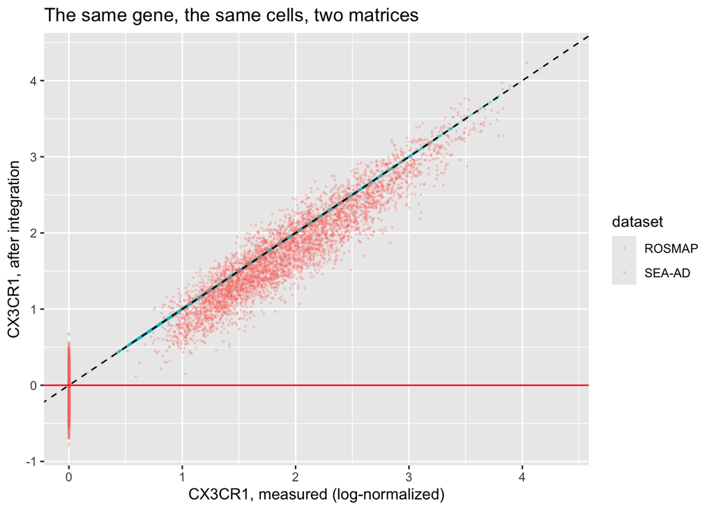

```r
compare_df <- data.frame(
  rna = rna_data[marker_gene, ],
  integrated = integrated_data[marker_gene, ],
  dataset = integrated$dataset)

gg <- ggplot2::ggplot(compare_df,
                      ggplot2::aes(x = rna, y = integrated, color = dataset))
gg <- gg + ggplot2::geom_point(size = 0.3, alpha = 0.2)
gg <- gg + ggplot2::geom_abline(slope = 1, intercept = 0, linetype = "dashed")
gg <- gg + ggplot2::geom_hline(yintercept = 0, color = "red")
gg <- gg + ggplot2::labs(x = paste0(marker_gene, ", measured (log-normalized)"),
                         y = paste0(marker_gene, ", after integration"),
                         title = "The same gene, the same cells, two matrices")
plot(gg)
```

The dashed line is where the two would agree. The red line is zero: everything below it is a value with no possible interpretation as an amount of RNA.

The colours make the asymmetry visible in one glance. **SEA-AD lies exactly on the dashed line** — every teal point, because those values were not changed. Every displaced point is ROSMAP, and so is the whole vertical stripe at `x = 0`: the cells where `CX3CR1` went undetected, spread by the correction across a band of invented values, a good part of it below the red line. This is the same fact the chunk above measured, drawn rather than counted, and it is the figure to keep in mind the next time a corrected matrix is offered to you as “the data”.

# 10 Re-embedding on the corrected values

```r
Seurat::DefaultAssay(integrated) <- "integrated"

integrated <- Seurat::ScaleData(integrated, verbose = FALSE)

set.seed(10)
integrated <- Seurat::RunPCA(integrated,
                             npcs = 30,
                             reduction.name = "pca.integrated",
                             verbose = FALSE)

set.seed(10)
integrated <- Seurat::RunUMAP(integrated,
                              reduction = "pca.integrated",
                              dims = 1:30,
                              reduction.name = "umap.integrated",
                              seed.use = 10,
                              verbose = FALSE)

Seurat::Reductions(integrated)
```

```
## [1] "pca.integrated"  "umap.integrated"
```

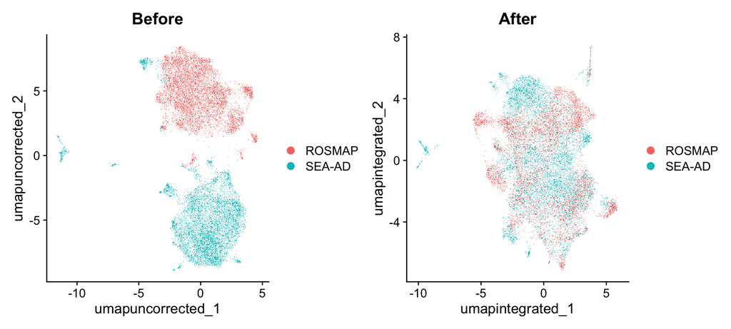

```r
gg1 <- Seurat::DimPlot(merged, reduction = "umap.uncorrected",
                       group.by = "dataset", raster = TRUE) +
  ggplot2::ggtitle("Before")
gg2 <- Seurat::DimPlot(integrated, reduction = "umap.integrated",
                       group.by = "dataset", raster = TRUE) +
  ggplot2::ggtitle("After")
plot(gg1 + gg2)
```

```r
mixing_integrated <- neighbor_mixing(
  embedding_mat = Seurat::Embeddings(integrated, "pca.integrated")[, 1:30],
  batch_vec = integrated$dataset,
  k = 30)

tapply(mixing_uncorrected, merged$dataset, stats::median)
```

```
## ROSMAP SEA-AD
##      0      0
```

```r
tapply(mixing_integrated, integrated$dataset, stats::median)
```

```
##     ROSMAP     SEA-AD
## 0.06666667 0.43333333
```

```r
1 - dataset_share
```

```
## dataset_vec
##    ROSMAP    SEA-AD
## 0.5166891 0.4833109
```

Read those three lines together, because the answer is more interesting than “it worked”.

Before correction both medians are **0**. After it, the two studies do not move the same distance: SEA-AD’s median rises to **0.43**, against a null of 0.48 — about as mixed as a balanced design allows. ROSMAP’s rises only to **0.07**, against a null of 0.52. Most ROSMAP nuclei still have 28 of their 30 neighbours from ROSMAP.

That is not a contradiction, and it is the reason to report this score **per batch** rather than pooled. Nearest-neighbour relationships are not symmetric, and we already know from the last section which side moved: ROSMAP. Enough ROSMAP nuclei were mapped into SEA-AD’s territory that a typical SEA-AD nucleus now has ROSMAP neighbours — but most ROSMAP nuclei were not, and still see only each other. The *Before* and *After* panels show the same thing geometrically: SEA-AD is a dense core, and ROSMAP is a larger cloud that closes over it only partly. A single pooled median would have landed between the two numbers and described neither study.

Whether that is good enough depends entirely on what you do next. It is fine for putting both studies on one set of axes. It is not a licence to say the two studies’ nuclei are now interchangeable.

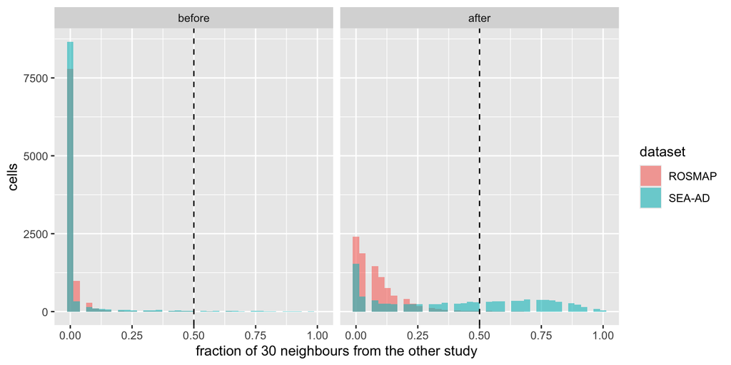

```r
mixing_df <- rbind(
  data.frame(mixing = mixing_uncorrected, dataset = merged$dataset,
             stage = "before"),
  data.frame(mixing = mixing_integrated, dataset = integrated$dataset,
             stage = "after"))
mixing_df$stage <- factor(mixing_df$stage, levels = c("before", "after"))

gg <- ggplot2::ggplot(mixing_df,
                      ggplot2::aes(x = mixing, fill = dataset))
gg <- gg + ggplot2::geom_histogram(bins = 40, alpha = 0.6,
                                   position = "identity")
gg <- gg + ggplot2::facet_wrap(~ stage)
gg <- gg + ggplot2::geom_vline(xintercept = 0.5, linetype = "dashed")
gg <- gg + ggplot2::labs(x = "fraction of 30 neighbours from the other study",
                         y = "cells")
plot(gg)
```

The dashed line is the balanced-design null. Read the *shape*, not only the median: a distribution piled at zero with a thin tail says most cells never left their own study; a broad distribution centred near the line says the mixing is general rather than driven by a handful of cells; and a bimodal one — a mixed population and an unmixed one — usually means a cell type that only one study captured.

All three are on this one panel, which is why the medians alone were not enough. ROSMAP is the first shape: piled against zero, with a tail that barely reaches 0.3. SEA-AD is the second and the third at once — a broad hump spread across the whole range, and *also* its own spike still sitting at zero. Those SEA-AD nuclei, the ones that found no ROSMAP neighbour at all, are the population to go and identify before interpreting anything: they are either a cell type ROSMAP’s middle temporal cortex did not capture, or a piece of SEA-AD the correction could find no anchor for. Which of the two it is cannot be settled from this figure.

> **Residual separation is not automatically a failure.** Two studies with different dissections and different chemistries can genuinely capture different states, and “the correction was incomplete” and “one study saw something the other did not” look identical in a UMAP. Telling them apart needs marker genes, not more integration. Week 3 hit the same ambiguity and left it standing for the same reason.

# 11 Going back to the counts

```r
Seurat::DefaultAssay(integrated) <- "RNA"
Seurat::DefaultAssay(integrated)
```

```
## [1] "RNA"
```

```r
SeuratObject::Layers(integrated[["RNA"]])
```

```
## [1] "scale.data" "data"       "counts"
```

This is the whole discipline in two lines. The corrected assay is still there, the reductions built from it are still there, and everything that reports a number about a gene now reads the measurements again.

The rule, stated once:

> **Cluster and visualize on the integrated output. Test on the original counts.**

The reason is not a convention and it is worth being able to say out loud. Integration deliberately removed variation it judged to be batch, using anchors that *assumed* the two studies contain the same cell types. A statistical test takes its input to be measurements with a known noise model — Poisson-ish counts, or something you are willing to treat as normal — and computes how surprising the observed difference is under that model. The corrected values are neither. They are reconstructions whose errors are correlated across cells in exactly the pattern the anchors imposed, and which have already had between-study differences shrunk toward zero. The p-value that comes out is a real number computed from the wrong thing; it does not come with a warning, and it is usually *smaller* than the honest one, because the correction removed the variance the test was supposed to be measuring against.

The right way to handle batch in a test is to keep it in the model rather than remove it from the data — a `~ batch + condition` design on pseudobulk, which is the companion Week 4 tutorial’s subject.

> **So what is the corrected matrix legitimately for?** It is a *presentation* and *input* layer, not an evidence layer.
> - Plotting a gene across batches — `FeaturePlot()`, `DotPlot()`, `VlnPlot()` — where an uncorrected panel would mostly show you which study each cell came from.
> - Heatmaps of a marker panel across studies, for the same reason.
> - Feeding a downstream method that wants a genes × cells matrix and has no batch term of its own: some trajectory methods, some matrix-factorization and gene-program methods.

> Everything on that list is descriptive. Nothing on it produces a p-value, a fold change, or a confidence interval. That is the line.

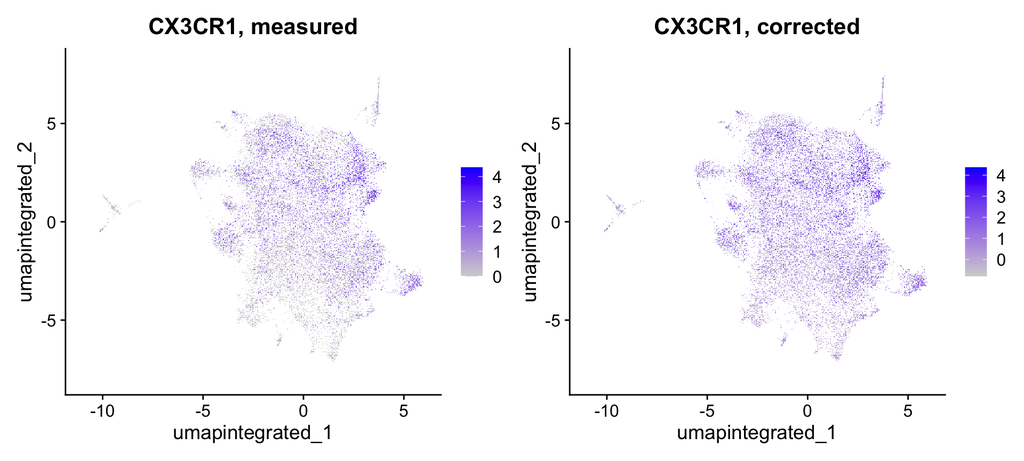

```r
Seurat::DefaultAssay(integrated) <- "RNA"
gg1 <- Seurat::FeaturePlot(integrated, features = marker_gene,
                           reduction = "umap.integrated", raster = TRUE) +
  ggplot2::ggtitle(paste0(marker_gene, ", measured"))

Seurat::DefaultAssay(integrated) <- "integrated"
gg2 <- Seurat::FeaturePlot(integrated, features = marker_gene,
                           reduction = "umap.integrated", raster = TRUE) +
  ggplot2::ggtitle(paste0(marker_gene, ", corrected"))

Seurat::DefaultAssay(integrated) <- "RNA"
plot(patchwork::wrap_plots(gg1, gg2, ncol = 2))
```

Two panels, one gene, one set of coordinates, one argument different — and the argument was never written down anywhere in the figure. If you make plots from both assays in the same analysis, put the assay in the title, every time.

The two panels also look more alike than they are, and by now you know why: half the cells on those axes are SEA-AD, and SEA-AD’s values are identical between them. Every difference you can see is a ROSMAP cell. A figure that averages a corrected study together with an uncorrected one, on shared axes, with no indication of which is which, is a fair description of most published integration figures.

# 12 The alternative that never edits expression: label transfer

There is a second thing people usually want when they reach for integration, and it does not require correcting anything. **What are my cells, in someone else’s vocabulary?** ROSMAP’s nuclei have `State` labels; SEA-AD’s have `Supertype` labels; the question is how they correspond.

This runs on the server too. `FindTransferAnchors()` is the same anchor machinery as `FindIntegrationAnchors()` — a different question asked of the same kind of search — so it is slow for the same reason, and it was computed by the same job. `predictions_df` came back in the `.RData` you loaded above.

```r
# Runs on the server, not here. See crossdataset-integration_server.R.
transfer_anchors <- Seurat::FindTransferAnchors(reference = seaad,
                                                query = rosmap,
                                                dims = 1:30,
                                                verbose = FALSE)

predictions_df <- Seurat::TransferData(anchorset = transfer_anchors,
                                       refdata = seaad$Supertype,
                                       dims = 1:30,
                                       verbose = FALSE)
```

```r
dim(predictions_df)
```

```
## [1] 9354   10
```

```r
utils::head(colnames(predictions_df))
```

```
## [1] "predicted.id"
## [2] "prediction.score.Micro.PVM_2"
## [3] "prediction.score.Micro.PVM_2_3.SEAAD"
## [4] "prediction.score.Micro.PVM_3.SEAAD"
## [5] "prediction.score.Micro.PVM_2_2.SEAAD"
## [6] "prediction.score.Micro.PVM_1"
```

```r
utils::head(predictions_df[, c("predicted.id", "prediction.score.max")], 5)
```

```
##                                                    predicted.id
## rosmap_MidtemporalCortex.AAAGTCCGTTCAAGTC-1         Micro-PVM_2
## rosmap_MidtemporalCortex.AACAAGAGTGATACAA-1         Micro-PVM_2
## rosmap_MidtemporalCortex.AAGCATCCACTAGGCC-1 Micro-PVM_2_3-SEAAD
## rosmap_MidtemporalCortex.AAGCGAGTCTCTAAGG-1         Micro-PVM_2
## rosmap_MidtemporalCortex.AATGGAATCTGTAACG-1         Micro-PVM_2
##                                             prediction.score.max
## rosmap_MidtemporalCortex.AAAGTCCGTTCAAGTC-1            0.4501119
## rosmap_MidtemporalCortex.AACAAGAGTGATACAA-1            0.8802829
## rosmap_MidtemporalCortex.AAGCATCCACTAGGCC-1            0.5412971
## rosmap_MidtemporalCortex.AAGCGAGTCTCTAAGG-1            0.7954446
## rosmap_MidtemporalCortex.AATGGAATCTGTAACG-1            0.6967688
```

```r
rosmap <- Seurat::AddMetaData(rosmap, metadata = predictions_df)

table(rosmap$predicted.id)
```

```
##
##         Micro-PVM_1         Micro-PVM_2 Micro-PVM_2_1-SEAAD Micro-PVM_2_3-SEAAD
##                  10                7410                  36                1533
##   Micro-PVM_3-SEAAD   Micro-PVM_4-SEAAD
##                 345                  20
```

```r
stats::quantile(rosmap$prediction.score.max)
```

```
##        0%       25%       50%       75%      100%
## 0.2584196 0.5947194 0.7473886 0.8961170 1.0000000
```

Note what did **not** happen: `rosmap` still holds its own counts, unmodified. The anchors were used to move a *label* rather than to move the data, so everything downstream — pseudobulk aggregation, DESeq2, composition testing — operates on measurements.

```r
label_tab <- table(rosmap$State, rosmap$predicted.id)
label_tab
```

```
##
##        Micro-PVM_1 Micro-PVM_2 Micro-PVM_2_1-SEAAD Micro-PVM_2_3-SEAAD
##   MG0            0        2397                   0                 240
##   MG1            0        1722                   0                 119
##   MG10           0          82                   0                  94
##   MG11           0         120                   0                  25
##   MG12           0          62                  36                  21
##   MG2            0         872                   0                 668
##   MG3            0         869                   0                 161
##   MG4            1         518                   0                  41
##   MG5            3         368                   0                  77
##   MG6            0          97                   0                  28
##   MG7            6         179                   0                  55
##   MG8            0         124                   0                   4
##
##        Micro-PVM_3-SEAAD Micro-PVM_4-SEAAD
##   MG0                  6                 0
##   MG1                 32                 0
##   MG10                 6                 0
##   MG11                 4                 0
##   MG12                 2                 0
##   MG2                  7                 0
##   MG3                 16                 0
##   MG4                185                 1
##   MG5                 78                 0
##   MG6                  0                17
##   MG7                  8                 2
##   MG8                  1                 0
```

```r
round(label_tab / rowSums(label_tab), 2)
```

```
##
##        Micro-PVM_1 Micro-PVM_2 Micro-PVM_2_1-SEAAD Micro-PVM_2_3-SEAAD
##   MG0         0.00        0.91                0.00                0.09
##   MG1         0.00        0.92                0.00                0.06
##   MG10        0.00        0.45                0.00                0.52
##   MG11        0.00        0.81                0.00                0.17
##   MG12        0.00        0.51                0.30                0.17
##   MG2         0.00        0.56                0.00                0.43
##   MG3         0.00        0.83                0.00                0.15
##   MG4         0.00        0.69                0.00                0.05
##   MG5         0.01        0.70                0.00                0.15
##   MG6         0.00        0.68                0.00                0.20
##   MG7         0.02        0.72                0.00                0.22
##   MG8         0.00        0.96                0.00                0.03
##
##        Micro-PVM_3-SEAAD Micro-PVM_4-SEAAD
##   MG0               0.00              0.00
##   MG1               0.02              0.00
##   MG10              0.03              0.00
##   MG11              0.03              0.00
##   MG12              0.02              0.00
##   MG2               0.00              0.00
##   MG3               0.02              0.00
##   MG4               0.25              0.00
##   MG5               0.15              0.00
##   MG6               0.00              0.12
##   MG7               0.03              0.01
##   MG8               0.01              0.00
```

Look at the totals before the proportions. Twelve ROSMAP states went in; **six** of SEA-AD’s eight supertypes came out, and one of them, `Micro-PVM_2`, accounts for **7,410 of 9,354** nuclei — 79%. Two SEA-AD supertypes were never predicted for any cell. A twelve-way distinction has been flattened into what is effectively a two-way one.

The row proportions are the readable version: for each ROSMAP state, where do those nuclei land in SEA-AD’s vocabulary? A row concentrated in one column is a state the reference recognizes — `MG8` goes 96% to `Micro-PVM_2`, `MG0` 91%. A row spread across several is a state the reference has no name for: `MG10` splits 45/52 between two supertypes, `MG2` 56/43. And a row can be *confidently* wrong, which the proportions cannot show you at all — that is what the next callout is about.

> **Label transfer cannot say “I do not know”.** Every query cell gets the reference’s best-matching label, whether or not the reference contains anything like it. A microglial activation state that SEA-AD’s supertypes do not resolve does not come back as unlabelled; it comes back as the nearest supertype, with a confident-looking integer count in a table. `prediction.score.max` is the only thing standing between you and that — cells whose best score is barely above their second-best are cells whose label you should not use. The quantiles above are worth sitting with: the median nucleus scores **0.75**, but the bottom quarter is below **0.59** and the weakest is **0.26** — a label with almost nothing behind it, reported in the same table, in the same font, as one scoring 1.00. Pick a floor, apply it, and say in your methods what it was.

> The same caution applies in reverse to the direction of the transfer. We made SEA-AD the reference because its annotation is the one being borrowed; running it the other way, with ROSMAP’s twelve states as the reference, is a different analysis and can disagree.

# 13 What we glossed over

- **We used CCA and compared it with nothing.** `FindIntegrationAnchors()` takes `reduction = "rpca"` (faster, more conservative — the recommended choice when the datasets are large or share little), and `IntegrateLayers()` in **Week 3** reaches Harmony, FastMNN and scVI through one argument. Running two methods and comparing them with the mixing score above costs one line and an hour, and “we used CCA because it was in the tutorial” is not a methods section.
- **Real integration metrics.** The neighbour-mixing score here is the idea behind LISI, boiled down to something you can read in the source. The published benchmarks — kBET, iLISI/cLISI, silhouette by batch and by label, and the composite scores in Luecken *et al.* — are what you would report. All of them pair a mixing measure with a biology-preservation measure, for the reason given above.
- **`SCTransform`.** Both routes accept `normalization.method = "SCT"`, but the anchor route additionally needs `PrepSCTIntegration()` before `FindIntegrationAnchors()`, and skipping it produces a wrong answer rather than an error. The **Week 3** normalization tutorial covers what SCTransform changes.
- **More than two datasets.** With many batches, `FindIntegrationAnchors(reference = c(1, 2))` integrates everything against a designated subset instead of all-against-all, which is the difference between an afternoon and a week. `sample.tree` in `IntegrateData()` controls the merge order, which is not cosmetic.
- **Choosing the reference deliberately.** We let the order of `list(seaad, rosmap)` decide which study was corrected onto which, discovered it afterwards by measuring, and left it. `IntegrateData(reference = ...)` and `FindIntegrationAnchors(reference = ...)` make it a stated choice. Running it the other way round is a different object and a different set of negative numbers, and nothing in either output would tell a reader which you did.
- **`k.anchor`, `k.filter`, `k.weight`.** Left at defaults. `k.weight` is the one that will actually break on you: it must not exceed the number of cells in the smallest dataset, and a small batch produces an error deep inside `IntegrateData()` that does not name the argument.
- **How many dimensions.** Thirty, everywhere, taken from the vignette and never defended — the same unexamined choice Week 3 flagged. It sets how much structure both the anchor-finding and the UMAP can see.
- **Five-sixths of ROSMAP.** We kept middle temporal cortex and discarded angular gyrus, entorhinal cortex, hippocampus, prefrontal cortex and thalamus — 123,653 nuclei — so that region would not be confounded with study. Integrating across regions *within* ROSMAP first, and then integrating that against SEA-AD, is a defensible alternative and a different tutorial: it treats region as a batch to be corrected rather than as a variable to be held fixed, which is a claim about regional microglial identity that you would have to be willing to defend.
- **Whether these two studies should be integrated at all.** They have no shared donors and no shared protocol, so “study” is confounded with everything about how the tissue was collected and processed. Integration will always produce output. Whether the aligned populations are the same biology is a claim the method cannot make for you.
- **Almost everything about the cluster.** We submitted one job, waited, and copied one file back. Not covered: `srun` for an *interactive* session on a compute node, which is where you should debug a script before ever calling `sbatch`; `future::plan("multicore")`, without which Seurat ignores the cores you asked for; job arrays, for running the same script over twenty samples; saving intermediate objects so a job that dies at minute fifty does not start from zero; and containers, which are how you make “the same R” mean the same thing on your laptop and on the cluster. How R is made available at all — `module load`, conda, a container — differs by cluster, and there is no answer that is right everywhere.
- **Cleaning.** Both objects arrive filtered by their authors, so **Week 2**’s ambient RNA and doublet work is invisible here. It comes first on your own data, and it comes first *per study* — ambient RNA profiles are study-specific.

# 14 References

- Stuart T, Butler A, Hoffman P, *et al.* (2019). “Comprehensive integration of single-cell data.” *Cell* 177:1888–1902. [doi:10.1016/j.cell.2019.05.031](https://doi.org/10.1016/j.cell.2019.05.031) — the anchor method used throughout this tutorial.
- Hao Y, Stuart T, Kowalski MH, *et al.* (2024). “Dictionary learning for integrative, multimodal and scalable single-cell analysis” (Seurat v5). *Nature Biotechnology* 42:293–304. [doi:10.1038/s41587-023-01767-y](https://doi.org/10.1038/s41587-023-01767-y)
- Luecken MD, Büttner M, Chaichoompu K, *et al.* (2022). “Benchmarking atlas-level data integration in single-cell genomics.” *Nature Methods* 19:41–50. [doi:10.1038/s41592-021-01336-8](https://doi.org/10.1038/s41592-021-01336-8) — the source for kBET, LISI and the mixing-versus-preservation framing.
- Sun N, Victor MB, Park YP, *et al.* (2023). “Human microglial state dynamics in Alzheimer’s disease progression.” *Cell* 186:4386–4403. [doi:10.1016/j.cell.2023.08.037](https://doi.org/10.1016/j.cell.2023.08.037) — the ROSMAP microglia and the `MG0`–`MG12` states. Project page: https://compbio.mit.edu/microglia_states/
- Gabitto MI, Travaglini KJ, Rachleff VM, *et al.* (2024). “Integrated multimodal cell atlas of Alzheimer’s disease” (SEA-AD). https://portal.brain-map.org/explore/seattle-alzheimers-disease
- Prater KE, Lin KZ (2025). “All the single cells: single-cell transcriptomics/epigenomics experimental design and analysis considerations for glial biologists.” *Glia* 73:451–473. [doi:10.1002/glia.24633](https://doi.org/10.1002/glia.24633) — §3.3 on batch correction covers this tutorial directly.